# Sabharwal-Shreya_PS2

#### Shreya Sabharwal

Collaborators: Sahil Aggarwal

```python
import numpy as np
import pandas as pd
import matplotlib.pyplot as plt
import time
```

### 1.1 Implement The 1D GA Algorithm

#### Question 1

As a warm-up exercise, your first task is to implement 1-dimensional version of GA. Let's look at 1D case with f(x) = -x^2. Pick an x0 (but don't pick x0 = 0), and set the learning rate R = 0.1. Start slow and manual. (a) What is the correct location of the maximum of this function? (b) What is the gradient vector of the function? What is it's dimension? (c) Compute the gradient at x0. (d) Compute x1 (e) Did we move closer to the maximum?

[figure not shown]

#### Question 2

Now repeat the previous exercise on computer.

Choose at least one stopping criterion and its parameter, and the bail-out number of iterations, R. Implement the above as an algorithm that at each step prints out the x value, the function's value f(x) and gradient rf(x). At the end it should print the solution, and also how many iterations it took for the loop to converge (to finish).

```python
# function f = -x^2 and its gradient -2x for 1-Dimensional Gradient Ascent
def f(x):
    return (-1)*x*x
def grad(x):
    return (-2)*x
```

```python
def gradient_ascent_1d(x0, R, max_iterations, epsilon=0.0001):
    """
    Function
    --------
    gradient_ascent_1d: implement 1-dimensional gradient ascent and print x, fx, gradient of x, number of iterations and
    maximum of fx

    Parameters
    ----------
    x0 : int, Value of x0
    R: float, Learning rate
    max_iterations: Int, maximum number of iterations
    """
    for i in range(max_iterations):
        #print ("x value:",x0)
        #print ("Function value:", f(x0))
        #print ("Gradient of the function", grad(x0),'\n')
        x1 = x0 + (R*grad(x0))

        #stopping condition
        if(abs(x1-x0) <=epsilon):
            print("Converged\n")
            break
        x0 = x1
    print("Number of Iterations:", i)
    print("Maximum of the function:", x1)
```

#### Question 3

Experiment with different starting values, learning rates and stopping parameter values. Comment and explain your findings.

```python
gradient_ascent_1d(x0=3, R=0.1, max_iterations=10000, epsilon=0.00001)
```

```
Converged

Number of Iterations: 50
Maximum of the function: 3.425394462494306e-05
```

```python
gradient_ascent_1d(x0=3, R=0.01, max_iterations=10000, epsilon=0.00001)
```

```
Converged

Number of Iterations: 431
Maximum of the function: 0.0004861675343895293
```

```python
gradient_ascent_1d(x0=100, R=0.01, max_iterations=10000, epsilon=0.01)
```

```
Converged

Number of Iterations: 263
Maximum of the function: 0.48270742904121117
```

```python
gradient_ascent_1d(x0=100, R=0.01, max_iterations=10000, epsilon=0.00000001)
```

```
Converged

Number of Iterations: 947
Maximum of the function: 4.81193504722288e-07
```

### 1.2 Implement The 2D Version

#### Question 4

Show that f(x) = -x'Ax describes a quadratic function. To show this, I recommend to write the function in non-matrix form as a formula explicitly in the components of x, x1 and x2.

[figure not shown]

#### Question 5.

What is the condition that the problem has a single maximum, i.e. f(x) <= 0 for all x? What's the location of it's true maximum?

[figure not shown]

#### Question 6

Compute the gradient vector of this function. Use the non-vector form you did under 4 above. Note: you may not be familiar with vector derivatives, but in vector form deltaf(x) = -(A' + A)x or - 2Ax as A is symmetric. Show that this is indeed true for the 2D case by taking the partial dericatives from the formula you computed in 4 above.

[figure not shown]

#### Question 7

Now code the algorithm above for 2D case. Do it in matrix form! As before, experiment with a few different learning rates and see how does this influence the speed of convergence. Comment and explain your findings.

```python
# function fx and its gradient for N-dimensional Gradient Ascent

def f_nd(x, A):
    return (-1)*x.T @ A @ x

def grad_nd(x, A):
    return (-1)*(A + A.T) @ x
```

```python
def gradient_ascent_nd(x0, A, R, max_iterations, xvalues, epsilon=0.000001):
    """
    Function
    --------
    gradient_ascent_nd: implement N-dimensional gradient ascent and print x, fx, gradient of x, number of iterations and
    maximum of fx

    Parameters
    ----------
    x0 : int, Value of x0
    A : matrix, 2 x 2 symmetric matrix
    R: float, Learning rate
    max_iterations: Int, maximum number of iterations
    xvalues: matrix, initial value of x0
    epsilon: stopping criteria for convergence
    """
    start_time = time.time()
    for i in range(max_iterations):
        #print ("x value:",x0)
        #print ("Gradient of the function", grad(x0, A),'\n')
        #Displaying first 10 value of f(x)
        if (i<=10):
            print("Function of x:", f_nd(x0, A))
        x1 = x0 + (R*grad_nd(x0, A))
        #print("Function of x1:", x1)
        xvalues = np.vstack((xvalues, x1.T))
        #stopping condition
        if(abs(x1-x0).any() <=epsilon):
            print ("Converged")
            break
        x0 = x1
    print("\nIterations:", i)
    print("\nMaximum of the function:", x1)
    print("\nTime taken:", time.time() - start_time)
    print("\nAll values of x:", xvalues)
    return xvalues
```

```python
x = np.matrix("2;-3")
print(x)
A = np.matrix("1,2; 2,8")
print(A)
```

```
[[ 2]
 [-3]]
[[1 2]
 [2 8]]
```

```python
saved_x1 = gradient_ascent_nd(x, A, 0.1, 10000, xvalues=x.T)
```

```
Function of x: [[-52]]
Function of x: [[-27.04]]
Function of x: [[-14.3936]]
Function of x: [[-7.923968]]
Function of x: [[-4.5640192]]
Function of x: [[-2.77884805]]
Function of x: [[-1.79865716]]
Function of x: [[-1.23601129]]
Function of x: [[-0.89480493]]
Function of x: [[-0.67487229]]
Function of x: [[-0.52431932]]
Converged

Iterations: 7555

Maximum of the function: [[  1.97626258e-323]
 [ -4.94065646e-324]]

Time taken: 0.539785623550415

All values of x: [[  2.00000000e+000  -3.00000000e+000]
 [  2.80000000e+000   1.00000000e+000]
 [  1.84000000e+000  -1.72000000e+000]
 ...,
 [  2.47032823e-323  -4.94065646e-324]
 [  1.97626258e-323  -4.94065646e-324]
 [  1.97626258e-323  -4.94065646e-324]]
```

```python
saved_x2 = gradient_ascent_nd(x, A, 0.01, 10000, xvalues=x.T)
```

```
Function of x: [[-52]]
Function of x: [[-36.7744]]
Function of x: [[-26.28244736]]
Function of x: [[-19.04696441]]
Function of x: [[-14.05184296]]
Function of x: [[-10.5981294]]
Function of x: [[-8.20503038]]
Function of x: [[-6.54181788]]
Function of x: [[-5.38098898]]
Function of x: [[-4.56604598]]
Function of x: [[-3.98933347]]

Iterations: 9999

Maximum of the function: [[  3.15694333e-41]
 [ -8.38371878e-42]]

Time taken: 0.7226669788360596

All values of x: [[  2.00000000e+00  -3.00000000e+00]
 [  2.08000000e+00  -2.60000000e+00]
 [  2.14240000e+00  -2.26720000e+00]
 ...,
 [  3.21699468e-41  -8.54319381e-42]
 [  3.18682756e-41  -8.46308067e-42]
 [  3.15694333e-41  -8.38371878e-42]]
```

#### Answer:

For the same value of x and different values of learning rate, we see that the number of iterations and subsequently the time taken to converge is more for smaller learning rate.

#### Question 8

Visualize your algorithm's work:Hint: look at the example notebook code.

Mark all the intermittend points (the x1-s) on the plot and connect these with lines. Note: you may want to save, instead of print, these values in your code now. In terms of showing the points on the figure, I recommend to plot the 100 first points, and the last point.

Add the function contours on the plot. In R you can use graphics::contour or ggplot2::geom_contour. In matplotlib plt.contour does a similar job. Note: try to use fixed 1:1 aspect ratio. Otherwise the direction of gradient does not coincide with that of the steepest ascent on the figure.

Explain what you see.

```python
def gradient_ascent_contour(xvalues, A, max_iterations, lev, param1=5, param2=5):
    """Plot contour for N-dimensional Gradient Ascent"""
    ## create 30x30 grid matrix
    n = 30
    ex1 = np.linspace(-param1, param1, num=n)
    ex2 = np.linspace(-param2, param2, num=n)
    grid1, grid2 = np.meshgrid(ex1, ex2)
    ## fill the grid via looping.  You may prefer to use ufuncs instead.
    z = np.empty_like(grid1)
    for i in range(z.shape[0]):
        for j in range(z.shape[1]):
            x = np.matrix([grid1[i,j], grid2[i,j]]).T
            z[i,j] = f_nd(x, A)

    ## Make the plot
    plt.figure(figsize=(9,9))
    p = plt.contour(grid1, grid2, z,
                    levels = lev,
                    colors = 'black')
    plt.clabel(p, inline=1, fontsize=10)
    xvalues = np.array(xvalues)
    maxval = min(100, len(xvalues))
    for i in range(maxval):
        plt.scatter(xvalues[i][0],xvalues[i][1], c='red', s=50)
        if(i>0):
            plt.plot([xvalues[i][0],xvalues[i-1][0]],[xvalues[i][1],xvalues[i-1][1]], c='red')
    plt.scatter(xvalues[-1][0],xvalues[-1][1], c='blue', s=50)
    plt.show()
```

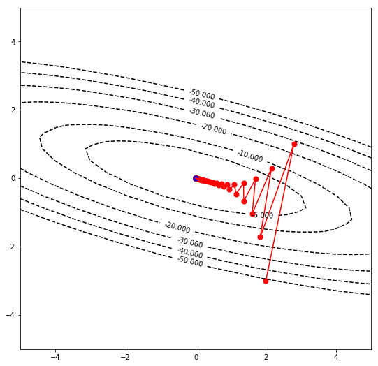

```python
levels = [-50, -40, -30, -20, -10, -5, 0, 5, 10, 20, 30, 40, 50]
gradient_ascent_contour(saved_x1, A, 10000, levels, param1=5, param2=5)
```

#### Answer:

For each subsequent value of x, the factor by which the value of x decreases also becomes smaller. The difference between the points that are near the origin cannot be clearly seen as these points are very close. They achieve convergence at the origin. The blue point at the origin is the last point.

#### Question 9

Finally, let's try if your code scales to 5D case without any modifications. Play with hyperparameters until you achieve convergence! Show and comment your results. In particular I'd like to see your comments comparing the easiness and speed of getting the 1D, 2D and 5D case to converge.

```python
x3 = np.matrix("10; 20; 30; 40; 50")
A3 = np.matrix(np.arange(1,26).reshape(5,5))
I5 = np.eye(A3.shape[0])
A3 = (A3 + A3.T)/2 + 10*I5
A3
```

```
matrix([[ 11.,   4.,   7.,  10.,  13.],
        [  4.,  17.,  10.,  13.,  16.],
        [  7.,  10.,  23.,  16.,  19.],
        [ 10.,  13.,  16.,  29.,  22.],
        [ 13.,  16.,  19.,  22.,  35.]])
```

```python
saved_x3 = gradient_ascent_nd(x3, A3, 0.01, 10000, xvalues=x3.T, epsilon=0.000001)
```

```
Function of x: [[-437500.]]
Function of x: [[-171775.]]
Function of x: [[-67543.75]]
Function of x: [[-26644.5775]]
Function of x: [[-10584.004375]]
Function of x: [[-4266.76959775]]
Function of x: [[-1773.00292544]]
Function of x: [[-780.91236411]]
Function of x: [[-379.70227103]]
Function of x: [[-211.92891949]]
Function of x: [[-137.17930539]]
Converged

Iterations: 9716

Maximum of the function: [[ -2.96439388e-323]
 [ -1.48219694e-323]
 [ -4.94065646e-324]
 [  4.94065646e-324]
 [  1.97626258e-323]]

Time taken: 0.9026665687561035

All values of x: [[  1.00000000e+001   2.00000000e+001   3.00000000e+001   4.00000000e+001
    5.00000000e+001]
 [ -1.90000000e+001  -2.00000000e+001  -2.10000000e+001  -2.20000000e+001
   -2.30000000e+001]
 [  1.00000000e-001   5.60000000e+000   1.11000000e+001   1.66000000e+001
    2.21000000e+001]
 ...,
 [ -3.45845952e-323  -1.97626258e-323  -4.94065646e-324   4.94065646e-324
    1.97626258e-323]
 [ -2.96439388e-323  -1.48219694e-323  -4.94065646e-324   4.94065646e-324
    1.97626258e-323]
 [ -2.96439388e-323  -1.48219694e-323  -4.94065646e-324   4.94065646e-324
    1.97626258e-323]]
```

#### Question 10

Compute the condition number for matrix A in the example above. Hint: consult Greene, Appendix 6.6, p 829. Note: a) Greene uses a slightly less common definiton of condition number, typically one uses just the fraction, not square root of it as Greene does. b) the words largest and smallest should be understood as largest and smallest in absolute value.

```python
valsA = np.linalg.eigvals(A3)
valsA
```

```
array([ 81.31043674,   3.68956326,  10.        ,  10.        ,  10.        ])
```

```python
cond_num_A = np.sqrt(np.max(abs(valsA))/np.min(abs(valsA)))
print(cond_num_A)
```

```
4.69446025401
```

### 1.3 Condition Numbers

#### Question 11

Show, on computer, that it is singular! Show it without error messages but using relevant linear algebra functions/properties instead.

```python
AA = np.matrix([[1,1],[1,1]])
np.linalg.det(AA)
```

```
0.0
```

```python
vals = np.linalg.eigvals(AA)
vals
```

```
array([ 2.,  0.])
```

```python
cond = np.sqrt(np.max(abs(vals))/np.min(abs(vals)))
print(cond)
np.linalg.cond(AA)
```

```
inf
```

```
59617770476389832.0
```

#### Answer:

Since the condition number of the matrix is very high, the matrix is singular. Also, since its determinant is zero, it is singular

#### Question 12

Let's a non-singular matrix C instead by adding a certain amount of unit matrix to it: C = A+(alpha)I2. Your task is to analyze and visualize the algorithm's work for three cases: alpha is 100, 1 or 0.01

Run your algorithm for each of these three cases. For each alpha: (a) report the hyperparameters (b) compute the corresponding C (c) print its eigenvalues and condition number. Please state which definition of eigenvalues you are using if not following Greene! (d) solve the problem using GA (e) report the location of maximum and the number of iterations it took (f) visualize the process using a figure, similar to the 8 above. Try to play with the 'level' argument of the contour plot to make the shape of the resulting object clear. Note: you may have to set different hyperparameters for different alphas.

```python
def question12(A12, alpha, R, eps, lev, param1=5, param2=5):
    print ("A matrix: ", A12)
    print ("Learning Rate: ",R)
    print ("\nDifference in the function value(epsilon):",eps)
    print ("\nAlpha:",alpha)
    C = A12 + alpha*np.eye(A12.shape[0])
    print ("C: ", C)
    cvals = np.linalg.eigvals(C)
    print("\neigenvalues: ",cvals)
    # definition of condition number from Greene
    cond = np.sqrt(np.max(abs(cvals))/np.min(abs(cvals)))
    print ("\ncondition num: ", cond)

    saved_x4 = gradient_ascent_nd(x, C, R, 10000, xvalues=x.T, epsilon=eps)
    gradient_ascent_contour(saved_x4, C, 10000,lev,param1,param2)
```

```python
A12 = np.matrix(AA)
A12
```

```
matrix([[1, 1],
        [1, 1]])
```

```
A matrix:  [[1 1]
 [1 1]]
Learning Rate:  0.005

Difference in the function value(epsilon): 1e-06

Alpha: 100
C:  [[ 101.    1.]
 [   1.  101.]]

eigenvalues:  [ 102.  100.]

condition num:  1.00995049384
Function of x: [[-1301.]]
Function of x: [[-0.0204]]
Function of x: [[ -8.16000000e-06]]
Function of x: [[ -3.26400000e-09]]
Function of x: [[ -1.30560000e-12]]
Function of x: [[ -5.22240000e-16]]
Function of x: [[ -2.08896000e-19]]
Function of x: [[ -8.35584000e-23]]
Function of x: [[ -3.34233600e-26]]
Function of x: [[ -1.33693440e-29]]
Function of x: [[ -5.34773760e-33]]
Converged

Iterations: 191

Maximum of the function: [[ 0.]
 [ 0.]]

Time taken: 0.022118330001831055

All values of x: [[  2.00000000e+000  -3.00000000e+000]
 [  1.00000000e-002   1.00000000e-002]
 [ -2.00000000e-004  -2.00000000e-004]
 [  4.00000000e-006   4.00000000e-006]
 [ -8.00000000e-008  -8.00000000e-008]
 [  1.60000000e-009   1.60000000e-009]
 [ -3.20000000e-011  -3.20000000e-011]
```

[output cut: 171 more lines]

```
 [ -1.91561943e-303  -1.91561943e-303]
 [  3.83123885e-305   3.83123885e-305]
 [ -7.66247770e-307  -7.66247770e-307]
 [  1.53249554e-308   1.53249554e-308]
 [ -3.06499108e-310  -3.06499108e-310]
 [  6.12998216e-312   6.12998216e-312]
 [ -1.22599643e-313  -1.22599643e-313]
 [  2.45199287e-315   2.45199287e-315]
 [ -4.90398592e-317  -4.90398592e-317]
 [  9.80799357e-319   9.80799357e-319]
 [ -1.96144061e-320  -1.96144061e-320]
 [  3.90311860e-322   3.90311860e-322]
 [ -9.88131292e-324  -9.88131292e-324]
 [  0.00000000e+000   0.00000000e+000]
 [  0.00000000e+000   0.00000000e+000]]
```

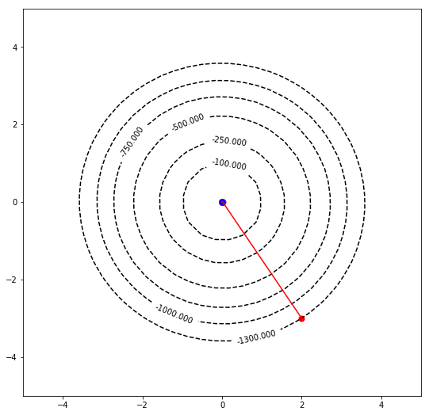

```python
levels = [-1300,-1000,-750, -500,-250,-100,0,100,250,500,750,1000,1300]
question12(A12, alpha =100, R=0.005, eps = 0.000001, lev=levels, param1=-5, param2=5)
```

```
A matrix:  [[1 1]
 [1 1]]
Learning Rate:  0.1

Difference in the function value(epsilon): 0.0001

Alpha: 1
C:  [[ 2.  1.]
 [ 1.  2.]]

eigenvalues:  [ 3.  1.]

condition num:  1.73205080757
Function of x: [[-14.]]
Function of x: [[-8.24]]
Function of x: [[-5.1584]]
Function of x: [[-3.282944]]
Function of x: [[-2.09813504]]
Function of x: [[-1.34233457]]
Function of x: [[-0.85901863]]
Function of x: [[-0.54975984]]
Function of x: [[-0.35184437]]
Function of x: [[-0.22518008]]
Function of x: [[-0.1441152]]
Converged

Iterations: 3336

Maximum of the function: [[  9.88131292e-324]
 [ -9.88131292e-324]]

Time taken: 0.22979307174682617

All values of x: [[  2.00000000e+000  -3.00000000e+000]
 [  1.80000000e+000  -2.20000000e+000]
 [  1.52000000e+000  -1.68000000e+000]
 ...,
 [  1.48219694e-323  -1.48219694e-323]
 [  9.88131292e-324  -9.88131292e-324]
 [  9.88131292e-324  -9.88131292e-324]]
```

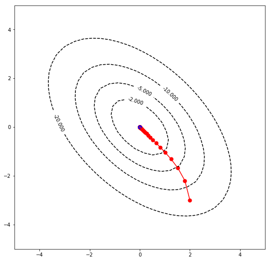

```python
levels = [-20,-10,-5,-2,0,2,5,10,20]
question12(A12, alpha =1, R=0.1, eps = 0.0001, lev=levels)
```

```
A matrix:  [[1 1]
 [1 1]]
Learning Rate:  0.1

Difference in the function value(epsilon): 1e-07

Alpha: 0.01
C:  [[ 1.01  1.  ]
 [ 1.    1.01]]

eigenvalues:  [ 2.01  0.01]

condition num:  14.1774468788
Function of x: [[-1.13]]
Function of x: [[-0.48389252]]
Function of x: [[-0.25252302]]
Function of x: [[-0.16946675]]
Function of x: [[-0.13944916]]
Function of x: [[-0.12839968]]
Function of x: [[-0.12413453]]
Function of x: [[-0.12229673]]
Function of x: [[-0.12132822]]
Function of x: [[-0.1206718]]
Function of x: [[-0.12012824]]

Iterations: 9999

Maximum of the function: [[  5.05071523e-09]
 [ -5.05071523e-09]]

Time taken: 0.7463390827178955

All values of x: [[  2.00000000e+00  -3.00000000e+00]
 [  2.19600000e+00  -2.79400000e+00]
 [  2.31120800e+00  -2.66881200e+00]
 ...,
 [  5.07097886e-09  -5.07097886e-09]
 [  5.06083690e-09  -5.06083690e-09]
 [  5.05071523e-09  -5.05071523e-09]]
```

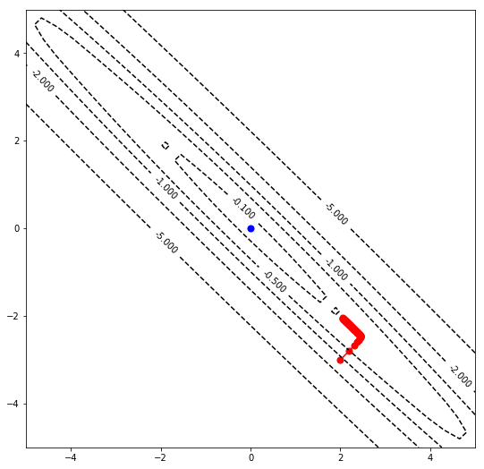

```python
levels4=[-5,-2,-1,-0.5, -0.1,0,0.1,0.5,1,2,5]
question12(A12, alpha =0.01, R=0.1, eps = 0.0000001, lev=levels4)
```

#### Question 13

Comment on your results. How is the convergence speed related to the matrix condition number?

Answer: Condition Number is higher for very small values of alpha as compared to higher values of alpha. The ones with higher condition number are taking more time to converge.

### 2. Outliers in different distributions

#### 2.1 Normal Distribution

Pick your number of repetitions R (1000 is a good choice), and sample sizes N (10, 1000, 100,000 are good choices, but you may want to adjust if the latter is too slow).

For R times create sample of N of standard normals, and take the mean of it. You'll have R means of N standard normals. Compute the mean-of-means, it's standard deviation, and 95% confidence region.

The 95% confidence region is the opposite of computing the percentage of observations that fit into the interval. The easiest way to find it is using sample quantiles. Check out the quantile function in R, or np.percentile function in python. For instance, np.percentile(x, 10) will give the 10th percentile q10 of an array x. 10th percentile is such a value that 10% of the sample values are smaller than that value.

Repeat the above with three different (and very different) N-s, such as 10, 1000, 100,000. Show how the mean-of-means, its standard deviation, and the confidence region depends on N.

```python
def normal_distr(R, N):
    mu = np.random.normal(size=(R,N)).mean(axis=1)
    print("Mean of means:", mu.mean())
    barx = mu.mean()
    std = np.sqrt(mu.var())
    print("Standard deviation:",std)
    x1 = np.percentile(mu, 97.5)
    x2 = np.percentile(mu, 2.5)

    outside = np.logical_or(mu < x2, mu > x1)
    print("confidence interval:", x2, x1)
    print("95% Confidence Region: ", outside.mean())
```

```python
normal_distr(R=1000,N=10)
```

```
Mean of means: -0.00244986510559
Standard deviation: 0.312586167036
confidence interval: -0.586558981646 0.643563015969
95% Confidence Region:  0.05
```

```python
normal_distr(R=1000,N=1000)
```

```
Mean of means: 0.000663457957267
Standard deviation: 0.031857307145
confidence interval: -0.058529632128 0.065141760164
95% Confidence Region:  0.05
```

```python
normal_distr(R=1000,N=100000)
```

```
Mean of means: 0.000157211355306
Standard deviation: 0.00316090730376
confidence interval: -0.00617413606765 0.00620097010967
95% Confidence Region:  0.05
```

#### 2.2 Pareto Distribution

Create a large number of pareto random variables. Show their distribution on a histogram. Attempt to make the histogram look good. Note: you'll see it is hard to make it to look good. But you may try to do it in log-log scale, and set an upper limit to the variables you will display, say only values x < 100 on the histogram.

```python
s = np.random.pareto(a=1, size = 1000)
```

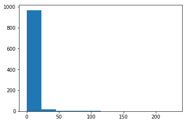

```python
plt.hist(s)
plt.show()
```

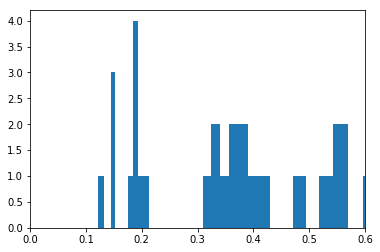

```python
plt.hist(s[:100],bins = np.logspace(np.log10(0.1),np.log10(1.0), 50))
plt.xlim(0, 0.6)
plt.show()
```

Pick R and three N values. Create R times a sample of N Pareto values, and take a mean of those. Compute the mean-of-the-means, it's standard deviation, and 95% confidence region. Repeat it with 3 different N-s. Finally compare your results for normal and Pareto distributions.

```python
def pareto_distr(R, N):
    np.random.seed(123)
    mu = (np.random.pareto(a=0.5, size=(R, N))+1).mean(axis=1)
    print ("mean of means: ", mu.mean())
    stddev1 = mu.std()
    print ("standard dev: ", stddev1)
    x1 = np.percentile(mu, 97.5)
    x2 = np.percentile(mu, 2.5)

    outside = np.logical_or(mu < x2, mu > x1)
    print("confidence interval:", x2, x1)
    print("95% Confidence Region: ", outside.mean())
```

```python
pareto_distr(1000, N=1000)
```

```
mean of means:  5636317.69049
standard dev:  165834745.652
confidence interval: 273.287325903 1177670.9369
95% Confidence Region:  0.05
```

```python
pareto_distr(1000, N=100)
```

```
mean of means:  30626.5260557
standard dev:  442896.809366
confidence interval: 33.339663621 125003.631803
95% Confidence Region:  0.05
```

```python
pareto_distr(1000, N=10)
```

```
mean of means:  11328.2248962
standard dev:  263321.274283
confidence interval: 3.70542016886 5888.7928085
95% Confidence Region:  0.05
```

#### Answer:

Compared to normal distributions, Pareto distributions have higher means and standard deviations. For k<=1, the denominator of expected value becomes very small and expected value shoots. The expected value for k<=1 doesn't have any significance as its value is very high and unstable unlike normal distribution as these distributions are highly skewed.